# Bonanza Creek exploratory report

#### B. Male and female juvenile snowshoe hare weight visualization

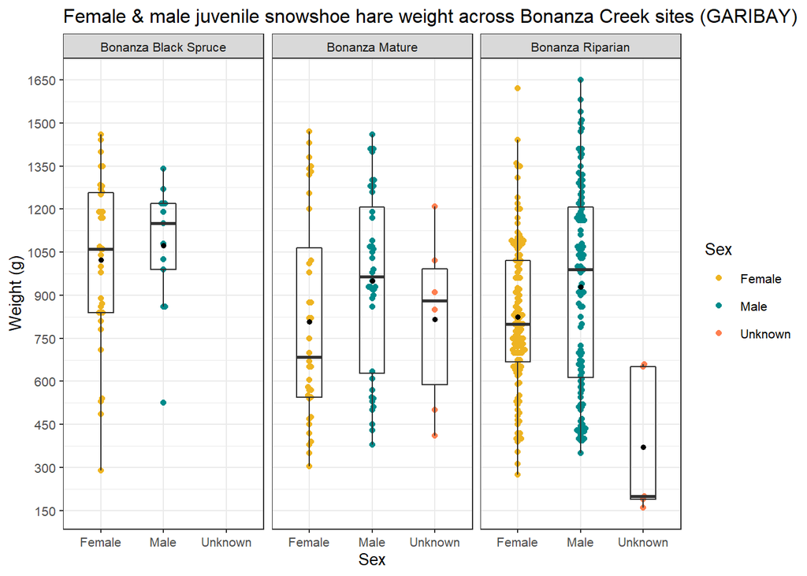

**Figure 2.** Female, male, and unknown juvenile snowshoe hare weight (g) observations across the Bonanza Creek Experimental Forest sites: Bonanza Black Spruce, Bonanza Mature, and Bonanza Riparian. yellow (Female), teal (Male), and orange (Unknown) points indicate individual observations for weight (g) of a juvenile snowshoe hare. Box endpoints indicate the 25th and 75th percentile values; the black line and black point within the box indicate the median and mean value for each sex, respectively. Data: Kielland et al. (2017).

#### C. Juvenile female and male snowshoe hare weight comparison

| Sex | Mean weight (g) | Standard deviation (g) | Sample size |
| --- | --- | --- | --- |
| Female | 855.3909 | 292.2526 | 197 |
| Male | 945.8589 | 333.2151 | 163 |
| Unknown | 614.5455 | 357.5853 | 11 |